# Exercise Week 3: Solutions

# fpp3 2.10, Ex 10

> The following time plots and ACF plots correspond to four different time series. Your task is to match each time plot in the first row with one of the ACF plots in the second row.

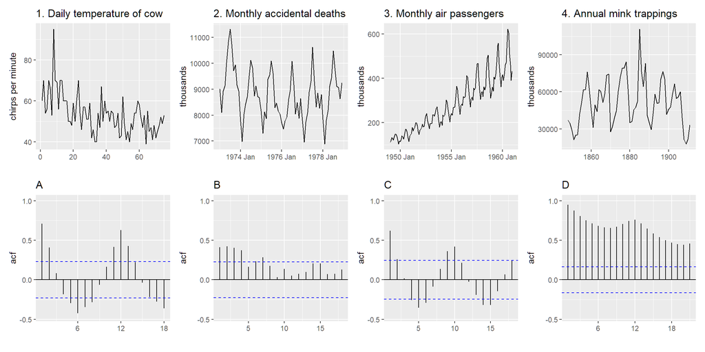

1-B, 2-A, 3-D, 4-C

# fpp3 2.10, Ex 11

> The `aus_livestock` data contains the monthly total number of pigs slaughtered in Victoria, Australia, from Jul 1972 to Dec 2018. Use `filter()` to extract pig slaughters in Victoria between 1990 and 1995. Use `autoplot` and `ACF` for this data. How do they differ from white noise? If a longer period of data is used, what difference does it make to the ACF?

```r
vic_pigs <- aus_livestock %>%
  filter(Animal == "Pigs", State == "Victoria", between(year(Month), 1990, 1995))
vic_pigs
```

```
## # A tsibble: 72 x 4 [1M]
## # Key:       Animal, State [1]
##       Month Animal State    Count
##       <mth> <fct>  <fct>    <dbl>
##  1 1990 Jan Pigs   Victoria 76000
##  2 1990 Feb Pigs   Victoria 78100
##  3 1990 Mar Pigs   Victoria 77600
##  4 1990 Apr Pigs   Victoria 84100
##  5 1990 May Pigs   Victoria 98000
##  6 1990 Jun Pigs   Victoria 89100
##  7 1990 Jul Pigs   Victoria 93500
##  8 1990 Aug Pigs   Victoria 84700
##  9 1990 Sep Pigs   Victoria 74500
## 10 1990 Oct Pigs   Victoria 91900
## # ... with 62 more rows
```

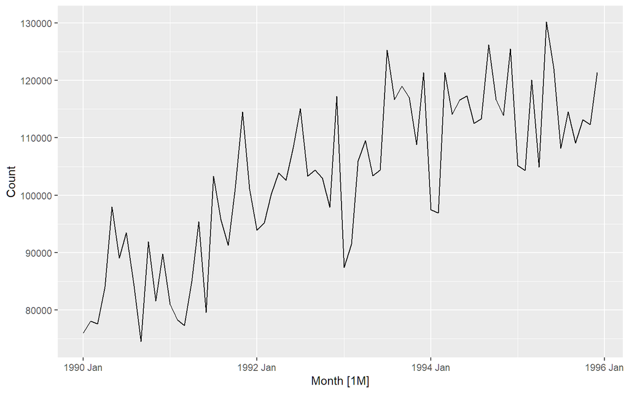

```r
vic_pigs %>%
  autoplot(Count)
```

Although the values appear to vary erratically between months, a general upward trend is evident between 1990 and 1995. In contrast, a white noise plot does not exhibit any trend.

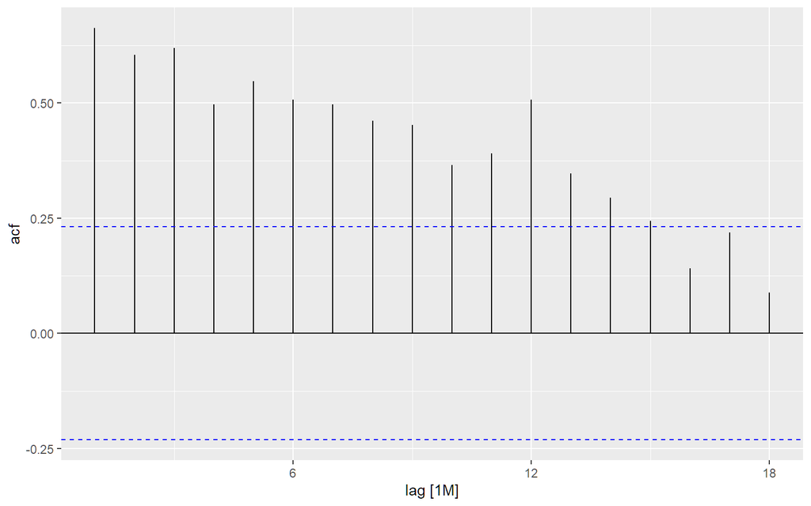

```r
vic_pigs %>% ACF(Count) %>% autoplot()
```

The first 14 lags are significant, as the ACF slowly decays. This suggests that the data contains a trend. A white noise ACF plot would not usually contain any significant lags. The large spike at lag 12 suggests there is some seasonality in the data.

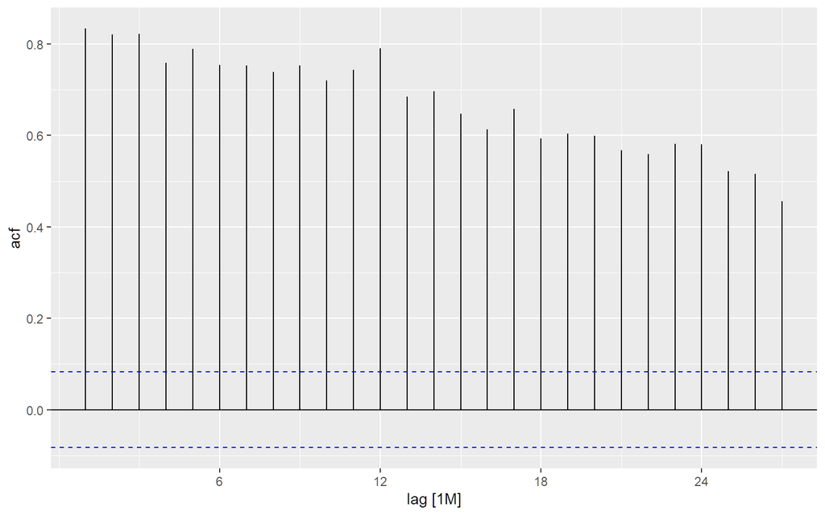

```r
aus_livestock %>%
  filter(Animal == "Pigs", State == "Victoria") %>%
  ACF(Count) %>%
  autoplot()
```

The longer series has much larger autocorrelations, plus clear evidence of seasonality at the seasonal lags of $12, 24, \dots$.

# fpp3 2.10, Ex 12

> 1. Use the following code to compute the daily changes in Google closing stock prices.

>    ```r
>    dgoog <- gafa_stock %>%
>      filter(Symbol == "GOOG", year(Date) >= 2018) %>%
>      mutate(trading_day = row_number()) %>%
>      update_tsibble(index = trading_day, regular = TRUE) %>%
>      mutate(diff = difference(Close))
>    ```

> 2. Why was it necessary to re-index the tsibble?
> 3. Plot these differences and their ACF.
> 4. Do the changes in the stock prices look like white noise?

```r
dgoog <- gafa_stock %>%
  filter(Symbol == "GOOG", year(Date) >= 2018) %>%
  mutate(trading_day = row_number()) %>%
  update_tsibble(index = trading_day, regular = TRUE) %>%
  mutate(diff = difference(Close))
```

The tsibble needed re-indexing as trading happens irregularly. The new index is based only on trading days.

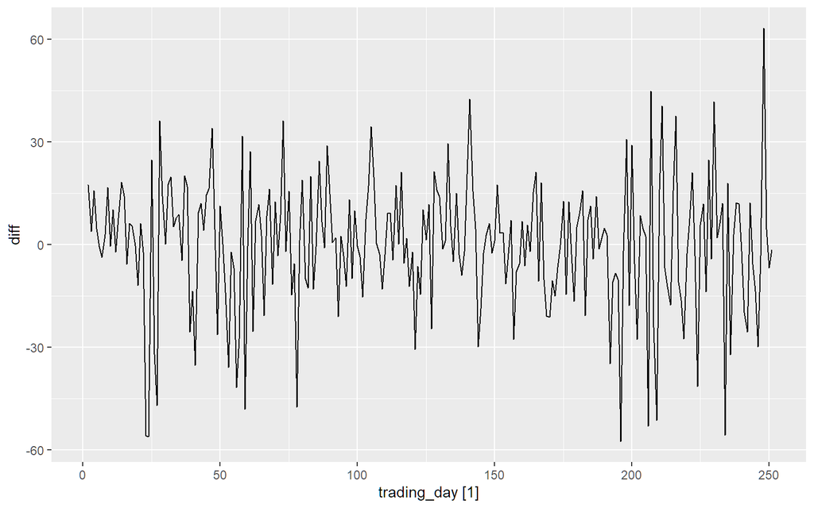

```r
dgoog %>% autoplot(diff)
```

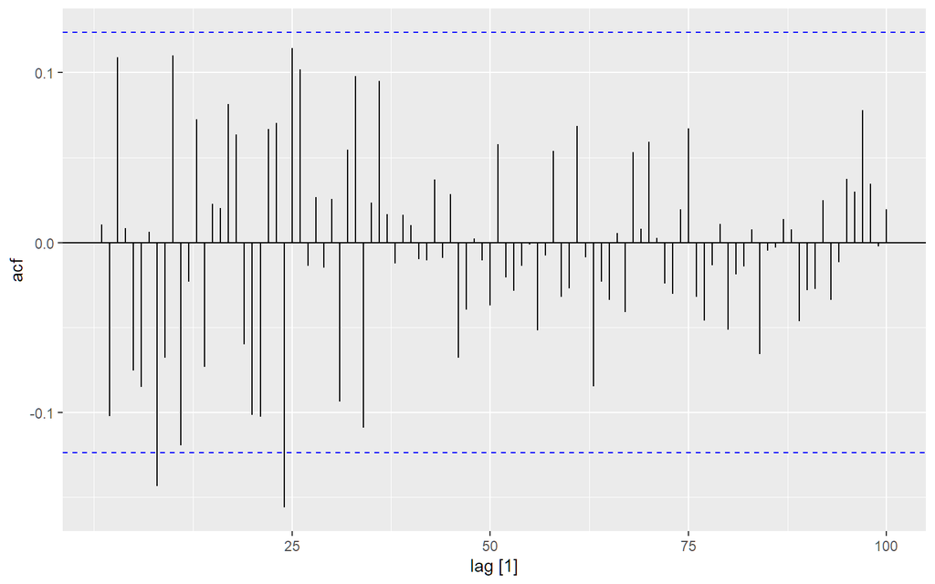

```r
dgoog %>% ACF(diff, lag_max=100) %>% autoplot()
```

There are some small significant autocorrelations out to lag 24, but nothing after that. Given the probability of a false positive is 5%, these look similar to white noise.